# Asssignment: Machine Learning

## Q10: compute skewness

```r
library(e1071)
sk <- sapply(data[num_var], skewness)
skew_df <- data.frame(Variable = names(sk), Skewness = round(as.numeric(sk), 3),
    Direction = ifelse(sk > 0, "Right-skewed (positive)", ifelse(sk < 0, "Left-skewed (negative)",
        "Symmetric")), Magnitude = ifelse(abs(sk) < 0.5, "Low / roughly symmetric",
        ifelse(abs(sk) < 1, "Moderate", "High")), row.names = NULL)
skew_df
```

```
          Variable Skewness               Direction               Magnitude
1              Age    0.279 Right-skewed (positive) Low / roughly symmetric
2           Income    0.713 Right-skewed (positive)                Moderate
3     Credit_Score   -0.148  Left-skewed (negative) Low / roughly symmetric
4      Loan_Amount    0.749 Right-skewed (positive)                Moderate
5 Employment_Years    0.422 Right-skewed (positive) Low / roughly symmetric
```

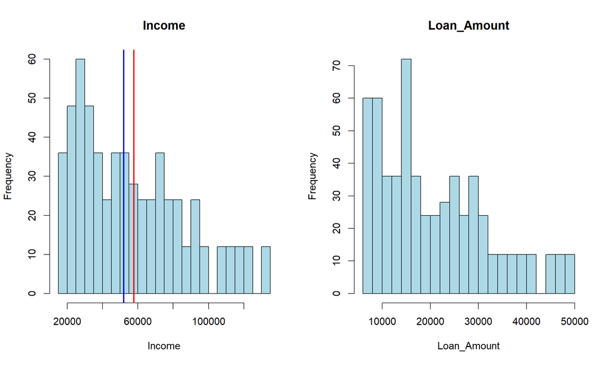

```r
par(mfrow = c(1, 2))
hist(data$Income, breaks = 30, col = "lightblue", main = "Income", xlab = "Income")
abline(v = mean(data$Income), col = "red", lwd = 2)
abline(v = median(data$Income), col = "blue", lwd = 2)
hist(data$Loan_Amount, breaks = 30, col = "lightblue", main = "Loan_Amount", xlab = "Loan_Amount")
```

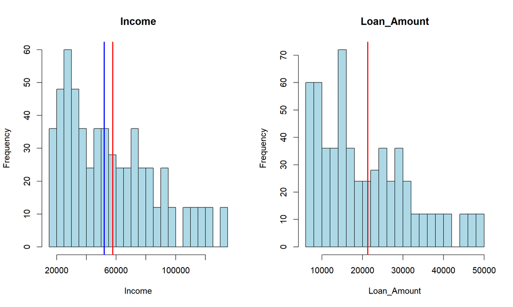

```r
abline(v = mean(data$Loan_Amount), col = "red", lwd = 2)
```

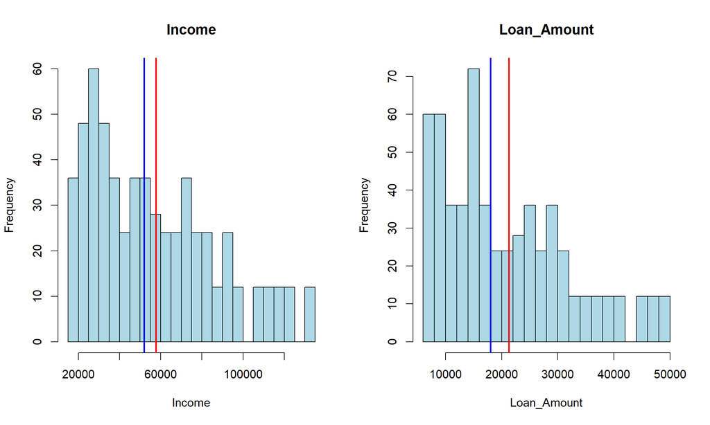

```r
abline(v = median(data$Loan_Amount), col = "blue", lwd = 2)
```

```r
par(mfrow = c(1, 1))
```

- The skewness of Income is 0.713 and of Loan_Amount is 0.749. Both are positive and fall in the 0.5–1 range, indicating moderate right-skewness. This means the majority of applicants have relatively modest incomes and take out smaller loans, while a smaller number of high-income applicants take much larger loans, producing a long right tail. The result is consistent with mean > median for both variables and with the shape of their histograms.

## Q11.class distribution of `Loan_Approved`. Is the dataset balanced or imbalanced?

```r
x <- data$Loan_Approved
if (is.factor(x)) {
    x <- as.character(x)
}
x_chr <- trimws(tolower(as.character(x)))
data$Loan_Approved <- factor(dplyr::case_when(x_chr %in% c("no", "n", "0", "false",
    "f") ~ "No", x_chr %in% c("yes", "y", "1", "true", "t") ~ "Yes", TRUE ~ NA_character_),
    levels = c("No", "Yes"))
print(table(data$Loan_Approved, useNA = "ifany"))
```

```
 No Yes
240 352
```

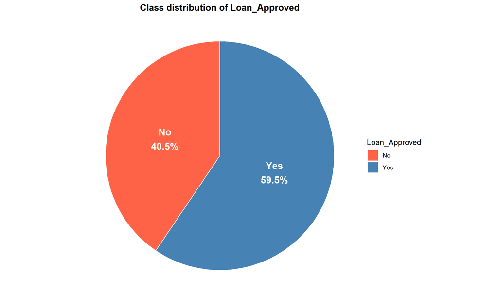

```r
class_counts <- table(data$Loan_Approved)
class_props <- prop.table(class_counts)
dist_df <- data.frame(Loan_Approved = names(class_counts), Count = as.integer(class_counts),
    Proportion = round(as.numeric(class_props), 3), Percent = paste0(round(100 *
        as.numeric(class_props), 1), "%"), row.names = NULL)
ggplot(dist_df, aes(x = "", y = Count, fill = Loan_Approved)) + geom_col(width = 1,
    colour = "white") + coord_polar(theta = "y") + geom_text(aes(label = paste0(Loan_Approved,
    "\n", Percent)), position = position_stack(vjust = 0.5), colour = "white", size = 5,
    fontface = "bold") + scale_fill_manual(values = c(No = "tomato", Yes = "steelblue")) +
    labs(title = "Class distribution of Loan_Approved", fill = "Loan_Approved", x = NULL,
        y = NULL) + theme_void() + theme(plot.title = element_text(hjust = 0.5, face = "bold"))
```

- The dataset is balanced — the Yes class is the majority at 59.5%, but the split is close to 60/40 and well within the accepted range for a balanced classification problem.

## Q12. Compute the correlation matrix for all numerical features.

```r
cor_mat <- cor(data[num_var], use = "complete.obs")
cor_df <- melt(round(cor_mat, 3))
colnames(cor_df) <- c("Variable_1", "Variable_2", "Correlation")
round(cor_mat, 3) |>
    as.data.frame() |>
    tibble::rownames_to_column("Variable")
```

```
          Variable   Age Income Credit_Score Loan_Amount Employment_Years
1              Age 1.000  0.982        0.970       0.837            0.991
2           Income 0.982  1.000        0.948       0.803            0.988
3     Credit_Score 0.970  0.948        1.000       0.862            0.965
4      Loan_Amount 0.837  0.803        0.862       1.000            0.842
5 Employment_Years 0.991  0.988        0.965       0.842            1.000
```